# Pitchfork Album Reviews

CUNY SPS IS 602 Nicholas Capofari

My final project was to create a program that extracts all of the album reviews from pitchfork.com. The following is my exploration of the more than 17,000 reviews Pitchfork has released since 1999.

```python
import pandas as pd
#set output options and import the data set
pd.set_option('max_colwidth',30)
pd.set_option('max_rows',500)
pd.set_option('expand_frame_repr',True)
p_df = pd.read_csv("pytchfork/data/all_pitchfork_albums.csv")
```

I ran into a good deal of trouble with the unicode strings that are found on pitchfork.com. I used the following to rid my data frame of any unicode issues.

```python
import sys
reload(sys)
sys.setdefaultencoding('utf-8')
def scrub(a_string):
    """helper function for utf-8 trouble"""
    return a_string.decode('utf-8', 'ignore')
p_df['artist'] = p_df.artist.apply(scrub)
```

The main unicode issue I had was with using the fuzzywuzzy package. Fuzzywuzzy was created by the developers at seatgeek.com. It's pretty cool. Fuzzywuzzy can take a string and a list of possible matching strings, and by using a string matching algorithim, return a list of similar strings, or the most similar string.

```python
from fuzzywuzzy import process
#set possible choices
choices = p_df['artist']
#artist to search for
artist = "yo la atngo!" #mispelled on purpose
#find the artist that is closest to the input
artist =  process.extractOne(artist, choices)[0]
#mini df for the given artist
info =  p_df.loc[p_df['artist'] == artist]
info[['artist', 'album', 'year', 'rating']]
```

|  | artist | album | year | rating |
| --- | --- | --- | --- | --- |
| 330 | Yo La Tengo | Stuff Like That There | 2015 | 7.1 |
| 1157 | Yo La Tengo | Extra Painful | 2014 | 9.6 |
| 3435 | Yo La Tengo | Fade | 2013 | 8.1 |
| 7347 | Yo La Tengo | Popular Songs | 2009 | 7.9 |
| 8451 | Yo La Tengo | They Shoot, We Score | 2008 | 7.3 |
| 10920 | Yo La Tengo | I Am Not Afraid of You and... | 2006 | 8.3 |
| 11356 | Yo La Tengo | Yo La Tengo Is Murdering t... | 2006 | 4.1 |
| 12672 | Yo La Tengo | Prisoners of Love | 2005 | 8.2 |
| 14119 | Yo La Tengo | Today Is the Day! EP | 2003 | 7.6 |
| 14828 | Yo La Tengo | Summer Sun | 2003 | 6.0 |
| 15180 | Yo La Tengo | Nuclear War EP | 2002 | 5.9 |
| 15478 | Yo La Tengo | The Sounds of the Sounds o... | 2002 | 8.0 |
| 16521 | Yo La Tengo | Danelectro EP | 2000 | 6.3 |
| 16813 | Yo La Tengo | And Then Nothing Turned It... | 2000 | 8.1 |

Below I took a look at how some of my favorite bands have been rated over the years.

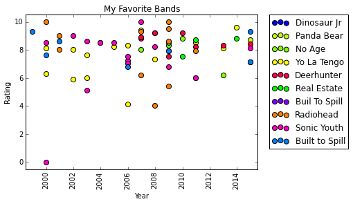

```python
#some of my favorite bands
%pylab inline
#variable names are favorite songs
bands = {"Built to Spill"    : '#007fff',
         "Radiohead"         : '#ff8000',
         "Sonic Youth"       : '#ff00bf',
         "Buil To Spill"     : '#7f00ff',
         "Panda Bear"        : '#bfff00',
         "No Age"            : '#80ff00',
         "Dinosaur Jr"       : '#0000ff',
         "Real Estate"       : '#00ff00',
         "Deerhunter"        : '#ff0040',
         "Yo La Tengo"       : '#ffff00'}
for key, value in bands.iteritems():
    faves = p_df.loc[p_df['artist'] == key]
    scatter(faves['year'], faves['rating'], c=value, s=50, label=key)
title('My Favorite Bands')
ylabel('Rating')
xlabel('Year')
axis([1998.5, 2015.5, -0.5, 10.5])
xticks(rotation='vertical')
legend(bbox_to_anchor=(1.05, 1), loc=2, borderaxespad=0.)
show()
```

I'm still upset with the 0 score for Sonic Youth's 2000 album "NYC Ghosts and Flowers". But I guess they made up for it with 2002's "Murray Street".

Here is a look at all of the reviews.

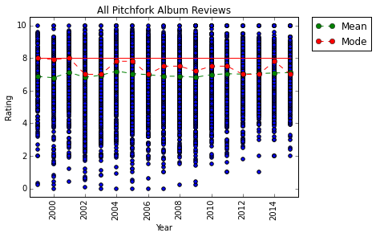

```python
#all reviews
years = range(1999, 2016)
means = []
modes = []
for year in years:
    means.append(mean(p_df[p_df.year == year].rating))
    temp = p_df[p_df.year == year].rating.mode()
    modes.append(temp.iloc[0])
plot(years, means, marker='o', linestyle='--', color='g', label='Mean')
plot(years, modes, marker='o', linestyle='--', color='r', label='Mode')
plot(years, np.repeat(8, [len(years)], axis=0), color='r')
scatter(p_df['year'], p_df['rating'])
title('All Pitchfork Album Reviews')
ylabel('Rating')
xlabel('Year')
axis([1998.5, 2015.5, -0.5, 10.5])
xticks(rotation='vertical')
legend(bbox_to_anchor=(1.05, 1), loc=2, borderaxespad=0.,)
show()
```

A major flaw with my entire approach is evident if you sort the albums by rating. If you notice, most of te following albums were *not* originally released betweeen 1999 and the present. Pitchfork reviews reissues as well as new albums. I took a few shots trying to remove them from the data set but did not succeed. This is something I would like to fix as I become more comfortable programming.

```python
p_df.sort_values(by=['rating', 'artist'],
                 inplace=True, ascending=[False, True])
p_df.head(12)[['artist', 'album', 'year', 'rating']]
```

|  | artist | album | year | rating |
| --- | --- | --- | --- | --- |
| 15891 | ...And You Will Know Us by... | Source Tags and Codes | 2002 | 10 |
| 74 | A Tribe Called Quest | People's Instinctive Trave... | 2015 | 10 |
| 8016 | Beastie Boys | Paul's Boutique | 2009 | 10 |
| 13712 | Boards of Canada | Music Has the Right to Chi... | 2004 | 10 |
| 16900 | Bonnie "Prince" Billy | I See a Darkness | 1999 | 10 |
| 11856 | Bruce Springsteen | Born to Run: 30th Annivers... | 2005 | 10 |
| 4664 | Can | Tago Mago [40th Anniversar... | 2011 | 10 |
| 3487 | D'Angelo | Voodoo | 2012 | 10 |
| 12418 | DJ Shadow | Endtroducing... [Deluxe Ed... | 2005 | 10 |
| 15701 | Elvis Costello & The Attra... | This Year's Model | 2002 | 10 |
| 3336 | Fleetwood Mac | Rumours | 2013 | 10 |
| 3945 | GZA | Liquid Swords: Chess Box D... | 2012 | 10 |

The following is a chart to track the amount of reviews that were written each year.

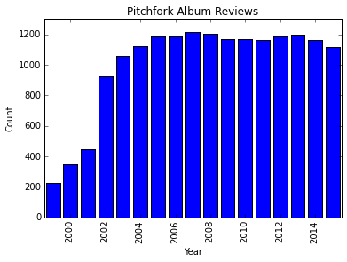

```python
p_df['year'] = p_df['year'].astype(float)
p_df.sort_values(by=['year'], inplace=True, ascending=False)
total_reviews = pd.value_counts(p_df['year'].values, sort=False)
bar(years, total_reviews, align='center')
title('Pitchfork Album Reviews')
ylabel('Count')
xlabel('Year')
axis([1998.5, 2015.5, 0, 1300])
xticks(rotation='vertical')
show()
```

Next, I wanted to see if Pitchfork's popularity has changed the way it reviews albums. I thought that the ratings that they issued would get lower as the site's popularity increased. But, it seems the opposite happened. As the years progressed the number of poor album reviews decreased.

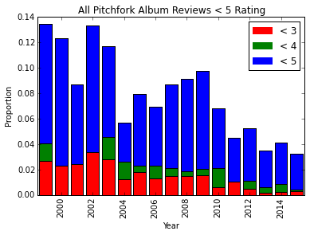

```python
import matplotlib.patches as mpatches
for year in years:
    temp = p_df[p_df.year == year]
    total = temp.shape[0]
    twos = (temp[temp['rating'] < 3].count())/total
    threes = ((temp[temp['rating'] < 4].count())/total) - twos[0]
    fours = ((temp[temp['rating'] < 5].count())/total) - threes[0]
    bar(year, twos[0], color='r', align='center')
    bar(year, threes[0], color='g', align='center', bottom=twos[0])
    bar(year, fours[0], color='b', align='center', bottom=threes[0])
title('All Pitchfork Album Reviews < 5 Rating')
ylabel('Proportion')
xlabel('Year')
axis([1998.5, 2015.5, 0, .14])
xticks(rotation='vertical')
L2 = mpatches.Patch(color='red', label='< 3')
L3 = mpatches.Patch(color='green', label='< 4')
L4 = mpatches.Patch(color='blue', label='< 5')
legend(handles=[L2,L3,L4])
show()
```

If we take a look at the higher rated albums, we can see a wave like pattern.

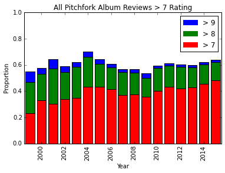

```python
for year in years:
    temp = p_df[p_df.year == year]
    total = temp.shape[0]
    temp = temp[temp.rating >= 7]
    sevens = ((temp[temp['rating'] < 8].count())/total).iloc[0]
    eights = ((temp[temp['rating'] < 9].count())/total).iloc[0] - sevens
    nines = ((temp[temp['rating'] >= 9].count())/total).iloc[0]
    bar(year, sevens, color='r', align='center')
    bar(year, eights, color='g', align='center', bottom=sevens)
    bar(year, nines, color='b', align='center', bottom=sevens+eights)
title('All Pitchfork Album Reviews > 7 Rating')
ylabel('Proportion')
xlabel('Year')
axis([1998.5, 2015.5, 0, 1])
xticks(rotation='vertical')
L7 = mpatches.Patch(color='red', label='> 7')
L8 = mpatches.Patch(color='green', label='> 8')
L9 = mpatches.Patch(color='blue', label='> 9')
legend(handles=[L9,L8,L7])
legend(bbox_to_anchor=(1.05, 1), loc=2, borderaxespad=0)
show()
```